# Migrating to Version 4 of the tmap R Package

Published

January 4, 2025

ABSTRACT

My favourite mapping package just released a major update! In this post I discuss the changes made as they relate to my work, and provide some tips and tricks I have learnt so far when migration from Version 3.0 to Version 4.0.

# 1 Introduction

The tmap package is one of my all time favourite R packages, and this latest update only solidified this opinion. I highly recommend that you check out the main page [here](https://r-tmap.github.io/tmap/index.html), and take the time to read over some of the documents in each of the tabs.

One of the most impactful updates in my opinion, is changes to the syntax used within a lot of the core functions. This new syntax makes things easier to understand, cleaner, and provides greater flexibility in the creation of your maps. However it can be a confusing journey to undergo the transition. You will find that for a lot of the old v3 code there are now warnings/pop-up messages to help you with the transition, but there are a few things that slip few the cracks and I think it is sometimes just easier to see some examples.

Below I run through how my code for making maps using tmap used to look, and then discuss the changes that have happened and how things look now!

**Note**

New datasets have also been added for demonstration purposes as well as the ability to extent tmap (to do things like map very unique spatial data types, or creating map overlays in a 3D environment). We won’t be covering those in this blog, but they are very interesting in their own right.

# 2 How things Used to Look

**Note**

For the purposes of this blog I will assume a basic understanding of the tmap package and won’t be explaining in detail what each function is/does.

Right, so in version 3.0, how did things look? Well, if I’m honest they looked a little messy. I found that there was only a moderate level of consistency between the arguments in each function, and that arguments within a function that matched together didn’t always make that fact obvious. For example, lets look at the arguments in the `tm_polygons()` function:

```r
tm_polygons(col,
            border.col,
            alpha,
            palette,
            legend.show,
            ...) #There are many more arguments in `tm_polygons()` than what I have listed, but the general idea remains the same for the rest.
```

… seems fine I guess. The arguments make sense, it looks like `col` would affect the colour of the polygon, and `border.col` would affect the border colour of the polygon. But what if I now add in the `tm_borders()` function:

```r
tm_borders(col,
           ...)
```

The two functions share the argument `col`. F `tm_polygons()` we are pretty sure that `col` affects the colour of the polygon, however this `tm_borders()` function sounds like it has been written specifically for the borders of polygons only… So now we need the additional context of knowing that “col” in `tm_polygons()` changes the colour inside the polygon, but in `tm_borders()` changes the colour of the border of the polygon. (Technically we could guess this from contextual clues such as how `tm_polygons()` also has a “border.col” argument but `tm_borders()` does not). Confusing! Moving on, lets look at the `alpha` (transparency) argument. Does that change the transparency of `col` or `border.col`? You would have to read the documentation to know that. What about the `palette` argument? Is that the colour palette for the `col` or `border.col` argument?… Extra confusing. But it gets worse! There is only one palette argument, so how do you change the palette for the inside of the polygon independently to the palette for the border of the polygons. You can’t, so thats where `tm_borders()` function comes in. Just making the conflict between `col` more obvious. Arrgh!

Enough ranting, lets look at a worked example of a map made using tmap version 3.0:

```r
#extract a subset of dat from the dataset provided with the tmap package
example_data <- NLD_muni |>
  filter(province == "Fryslan")

#create a map using the version 3.0 syntax
v3_map <- tm_shape(example_data) +
  tm_polygons(col = "name", border.col = "black", alpha = 0.8, palette = "Pastel1", legend.show = T) +
  tm_text("name", shadow = T, auto.placement = T, size = 0.6) +
  tm_shape(example_data) +
  tm_borders("name") +
  tm_layout(legend.bg.color = "white", legend.frame.color = "black", asp = 1.1,
            legend.outside = TRUE)
```

Again. Overall it doesn’t look too bad, with enough patience we can piece together what things probably do, and by trial and error we can confirm our ideas. However, it is when this code is compared to the new code that the short comings become apparent.

By the way, here is what the map produced by this code looks like:

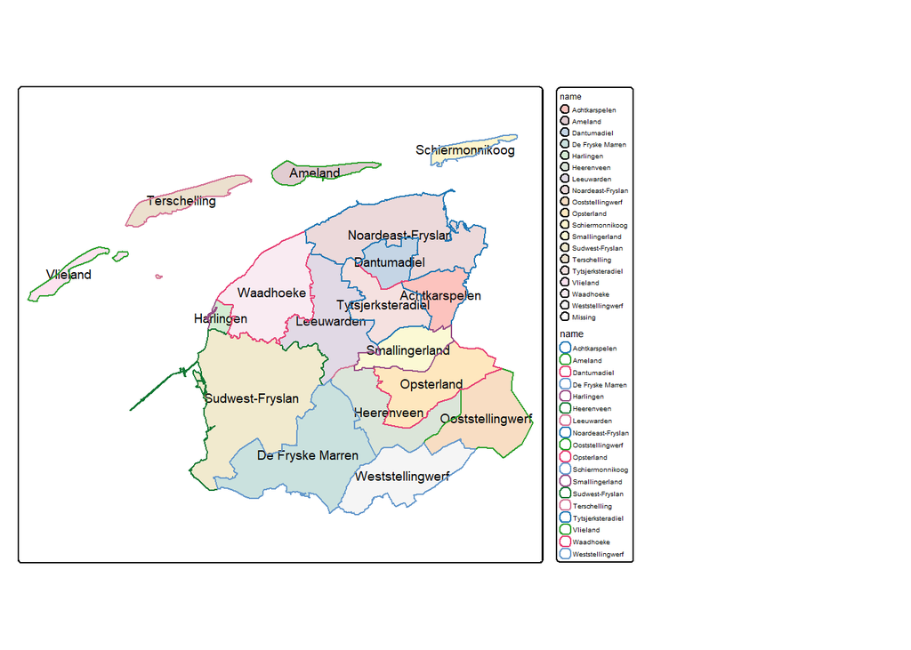

```r
#print the map
v3_map
```

# 3 How Things Look Now

Compared to Version 3.0, the new syntax available with tmap version 4.0 is much more consistent, concise, and also somehow does more with less. For example, lets look at the arguments in the `tm_polygons()` function again, right now we will just replace 1 to 1 the arguments we looked at before:

```r
tm_polygons(fill, #this was "col"
            col, #this was "border.col"
            fill_alpha, #this was "alpha"
            fill.scale, #this was "palette"
            fill.legend, #this was "legend.show"
            ...)
```

At first glance this doesn’t seem a whole lot better, there are now just a lot of “fill” arguments. But lets have a look at `tm_borders()` now:

```r
tm_borders(col, #this was "col", and still is "col"
           ...)
```

Right away we can see the first problem has been addressed. `col` now always refers to the colour of the line/outline/border, whereas `fill` always refers to the inside/fill of the shape. Secondly, the confusion around `alpha` has been removed, we can see that `alpha` is now `fill_alpha`, but even cooler, there is actually also a `col_alpha` now, the alphas’ are independent! The same logic has been applied to `palette`, which is now `fill.scale` (too detailed to explain that change right now), and the legend arguments, which now have “fill” in front of them. So what we have now is something like this:

```r
tm_polygons(fill, #what variable defines the "fill" of the polygons
            fill.scale, #what palette, breaks, style, should the be used to colour the polygons
            fill.legend, #do you want a legend? What should it look like for the fill variable
            fill.free, #should the scale be free for multiples (facets etc.)
            fill_alpha, #how transparent should the fill colour be
            col, #what variable defines the "col" (border) of the polygons
            col.scale, #what palette, breaks, style, should the be used to colour the borders
            col.legend, #do you want a legend? What should it look like for the col variable
            col.free, #should the scale be free for multiples (facets etc.)
            col_alpha, #how transparent should the border colour be
            ...)
```

It couldn’t be more obvious what each argument does now. Lets now make the same map as above, but this time with the version 4.0 syntax:

```r
#create a map using the version 4.0 syntax
v4_map <- tm_shape(example_data) +
  tm_polygons(fill = "name",
              fill.scale = tm_scale_categorical(values = "brewer.pastel1"),
              fill.legend = tm_legend(show = T),
              fill_alpha = 0.8,
              col = "name",
              col.scale = tm_scale_categorical(values = "brewer.set2"),
              col.legend = tm_legend(show = T)) +
  tm_text("name",
          size = 0.6,
          options = opt_tm_text(shadow = TRUE,
                                point.label = TRUE)) +
  tm_layout(legend.bg.color = "white",
            legend.frame.color = "black",
            legend.outside.position = tm_pos_out("right", "top"),
            asp = 1.1)
```

Two things are obvious in this code.

1. Which arguments should be associated with each other
2. The code looks slightly more verbose, but this is due to less assumptions by the functions, and more explicit directions by me

Side note, you may have also noticed I have changed the structure of my code. This is purely to assist in determining which arguments match together.

Here is what the map produced by this code looks like:

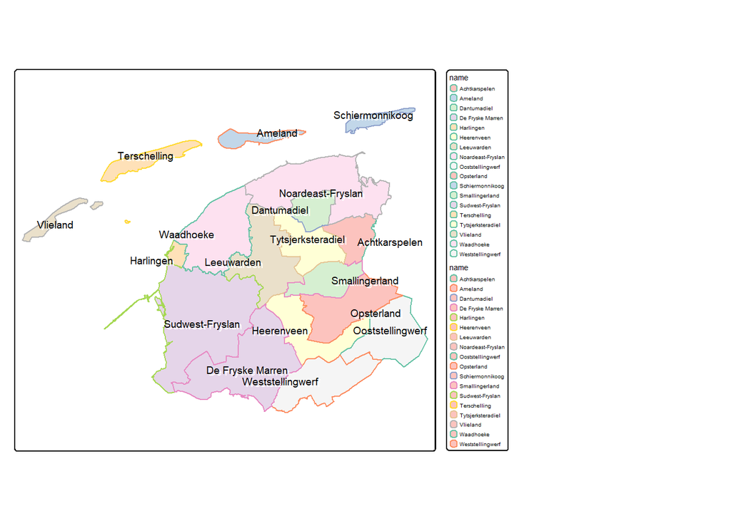

```r
#print the map
v4_map
```

Ignoring the fact that for both examples these aren’t the most visually appealing maps, it is now very easy to isolate exactly what each argument does and how we can adjust different aspects of the map. Alongside the changes surrounding the `fill` and `col` arguments, some other changes include:

- The arguments: `shadow = TRUE`, and `auto.placement = TRUE`, have been nested under the new argument `options`, which has its own helper function `opt_tm_text()`. (`auto.placement` has also been changed to `point.label`). +
  - Thus: `options = opt_tm_text(shadow = TRUE, point.label = TRUE)`
- More helper functions have been added such as the afor mentioned `opt_tm_text()`, the various scale helpers `tm_scale_...`, and functions for positioning things such as `tm_pos_out`.
  - I never used to really use the helper functions before this update, but they really do make things easier. For a deeper dive on these, check out my other blog post: Making Beautiful Maps in R

# 4 A Visually Appealing Map

Okay lets be honest, I’ve been doing a lot of posturing without actually creating a map that is even remotely visually appealing. Thus, lets produce a map that is actually not half bad! Here is one I prepared earlier:

**Note**

There is a lot of code that happens to produce this map, if you’re interested in learning whats going on, I break it down in detail over in my other blog post: Making Beautiful Maps in R

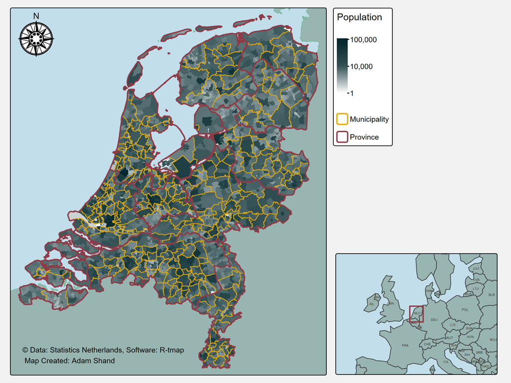

Beautiful Map of Netherlands

That looks pretty good, right?

# 5 Some Other Changes

Before I’m done, I’d like to drop a few more findings. Not only is the syntax of version 4 better, or the consistency improved, or just the visuals of the maps better. But the method for a bunch of other aspects has been improved as well. This includes things such as mapping raster data types, and faceting maps. Lets cover both at once!

Before the update this is how I used to create a faceted map of rasters (noting this code won’t work right now as the data isn’t available). I had to create a map for each year of data individually, then keep track of which map I was on. For the first map I created a legend, and for all other maps I didn’t create a legend. Finally, I had to stitch all of these maps together, and then I could save the result.

```r
#using unique regions
for (i in n3_marine_names) {

  #filter all basins by region
  region_basins <- n3_marine_region |> filter(Region == i)

  #get the associated basins
  basins <- n3_basins |> filter(Region == i)

  #create counter for j loop
  count <- 0

  #using years vector created by data sourcing script
  for (j in time(n3_dhw_5y)){

    #track counter
    count <- count + 1

    #mask to the specific region and year
    single_year_region <- trim(mask(n3_dhw_5y[[time(n3_dhw_5y) == j]], vect(region_basins)))

    #for the first map make a legend
    if (count == 1){

      #plot
      map <- tm_shape(single_year_region) +
        tm_raster(palette = dhw_cols, breaks = c(1:6), labels = dhw_lab) +
        tm_shape(qld) +
        tm_polygons(col = "grey80", border.col = "black") +
        tm_shape(region_basins, is.master = T) +
        tm_borders(col = "black") +
        tm_shape(basins) +
        tm_polygons(col = "grey90", border.col = "black") +
        tm_layout(asp = 5, legend.show = F, main.title = year(time(single_year_region)), main.title.position = "centre")

      #save the map
      assign(glue("map{count}"), map)

      #make a legend map
      legend_map <- tm_shape(single_year_region) +
        tm_raster(palette = dhw_cols, breaks = c(1:6), labels = dhw_lab, legend.reverse = T,
                  title = "Coral bleaching likelihood \n and number of DHW's") +
        tm_layout(legend.only = T, legend.title.size = 3,
                  legend.text.size = 1.6, legend.position = c(0, 0.3))

    #otherwise, no legend
    } else {

      #plot
      map <- tm_shape(single_year_region) +
        tm_raster(palette = dhw_cols, breaks = c(1:6), labels = dhw_lab) +
        tm_shape(qld) +
        tm_polygons(col = "grey80", border.col = "black") +
        tm_shape(region_basins, is.master = T) +
        tm_borders(col = "black") +
        tm_shape(basins) +
        tm_polygons(col = "grey90", border.col = "black") +
        tm_layout(asp = 5, legend.show = F, main.title = year(time(single_year_region)), main.title.position = "centre")

      #save the map
      assign(glue("map{count}"), map)

    }
  }

  #arrange into two rows
  facet_map <- tmap_arrange(map1, map2, map3, map4, map5, nrow = 2)

  #edit variable name for better save path
  i_lower <- tolower(gsub(" ", "-", i))

  #save the map as a png
  tmap_save(facet_map, filename = glue("{output_path}/plots/{i_lower}_dhw_fyear-{current_fyear}-to-{current_fyear-4}.png"))

  #save the legend separately
  tmap_save(legend_map, glue("{output_path}/plots/{i_lower}_dhw_fyear-{current_fyear}-to-{current_fyear-4}_legend.png"))

}
```

And this is how I create them now. The change is purely down to the introduction of the `tm_facets_...` group of functions, which are modelling after the ggplot2 `facet_wrap` functions if you are familiar. Without a doubt, much easier, much simpler, much quicker to understand.

```r
#plot
facet_map <- tm_shape(all_year_region) +
  tm_raster(col.scale = tm_scale_intervals(values = dhw_cols,
                                           breaks = c(1:6),
                                           labels = dhw_lab),
            col.free = FALSE,
            col.legend = tm_legend(title = "Coral bleaching likelihood and number of DHW's")) +
  tm_shape(qld) +
  tm_polygons(fill = "grey80",
              col = "black") +
  tm_shape(region_basins, is.main = T) +
  tm_borders(col = "black") +
  tm_shape(basins) +
  tm_polygons(fill = "grey90",
              col = "black") +
  tm_layout(panel.labels = year(time(n3_dhw_5y))) +
  tm_facets_hstack()

#save the map as a png
tmap_save(facet_map, filename = glue("{output_path}/plots/{i_lower}_dhw_fyear-{current_fyear}-to-{current_fyear-4}.png"))
```

# 6 Caveats

This blog has been written documenting some of the changes that have occurred with the R package “tmap”. I explain how some of the changes have impacted my work, and cover a few instances where the update from v3 to v4 might not be so obvious. However! In no way am I pretending to understand all of the changes that have occurred. I would highly recommend visiting the main tmap page [here](https://r-tmap.github.io/tmap/index.html).

# Thanks For Reading!

Please stick around, and have a read of several of my other posts. You'll find work on everything from simple data management and organisation skills, all the way to writting custom functions, tackling complex environmental problems, and my journey when learning new environmental data analyst skills.

A work by [Adam Shand.](https://github.com/add-am/) Reuse: [CC-BY-NC-ND.](https://creativecommons.org/licenses/by-nc-nd/4.0/deed.en)

*adamshand22@gmail.com*

[Buy Me a Coffee!](https://www.buymeacoffee.com/adamshand22)